# w203_Lab3_group5_draft1: Joanna wang, Douglas(Zeliang) Xu

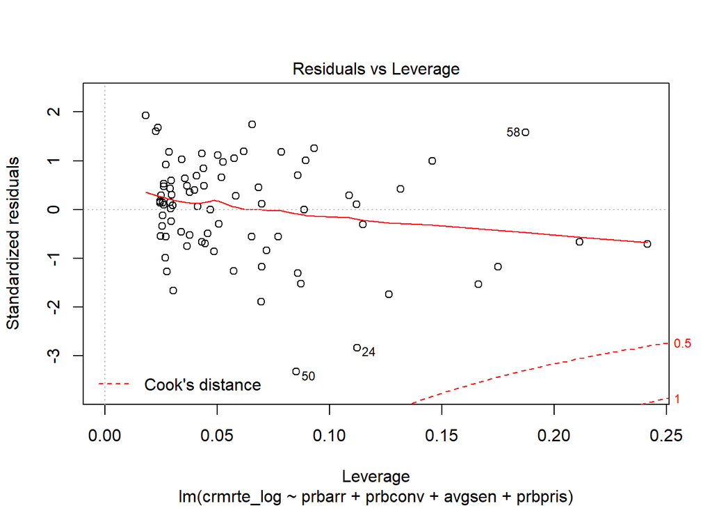

```r
plot(model1,which = 5)
```

The above plot shows that even though there are some points that have high leverage, but since it stays within the 0.5 Cook’s distance, there is nothing that we need to worry about.

Next, we are doing a t-test for the coefficients to see whether they have statistical significance

```r
coeftest(model1,vcov=vcovHC)
```

```
##
## t test of coefficients:
##
##               Estimate Std. Error t value  Pr(>|t|)
## (Intercept) -2.3847606  0.5030916 -4.7402 9.755e-06 ***
## prbarr      -2.6261600  0.5414970 -4.8498 6.413e-06 ***
## prbconv     -0.9617120  0.3524799 -2.7284  0.007902 **
## avgsen       0.0090325  0.0218154  0.4140  0.680008
## prbpris      0.1002884  0.7078536  0.1417  0.887708
## ---
## Signif. codes:  0 '***' 0.001 '**' 0.01 '*' 0.05 '.' 0.1 ' ' 1
```

Now we want to test whether the two explanatory variables that are not statistically significant are jointly significant, we build a model1.1 with just $prbarr$ and $prbconv$

```r
model1.1 <- lm(crmrte_log ~ prbarr + prbconv, data=data_clean)
```

To test whether the difference in fit is significant, we use the wald test, which generalizes the usual F-test of overall significance, but allows for a heteroskedasticity-robust covariance matrix

```r
waldtest(model1, model1.1, vcov = vcovHC)
```

```
## Wald test
##
## Model 1: crmrte_log ~ prbarr + prbconv + avgsen + prbpris
## Model 2: crmrte_log ~ prbarr + prbconv
##   Res.Df Df      F Pr(>F)
## 1     76
## 2     78 -2 0.1015 0.9036
```

**Summary for model 1**  
1. There are strong evidence that omitted variables exist for model1, and it leading to biases.Therefore, in the second model, we will add more covariates that we believe to be relevant and can help us reduce the omitted variable biases. 2. We need to use robust standard errors when looking at the model standard errors. 3. Only $prbarr$ and $prbconv$ are statistically significant 4. The above results suggest that the variable $avgsen$ and $prbpris$ are not jointly significant.Therefore, we have decided to remove the two variables from our model specification, and thus we are not going to use them for policy suggestions.